# Research_Project1

###Checking for duplicates

```r
#Checkcing for Duplicates and unique values


any(duplicated(advertising))
```

```
## [1] FALSE
```

```r
##Rows

duplicated_rows <- advertising[duplicated(advertising),]




duplicated_rows <- advertising[duplicated(advertising),]
duplicated_rows
```

```
## Empty data.table (0 rows and 10 cols): Daily Time Spent on Site,Age,Area Income,Daily Internet Usage,Ad Topic Line,City...
```

```r
#Seeing Unique values



unique_items <- advertising[!duplicated(advertising), ]

unique_items
```

```
##       Daily Time Spent on Site Age Area Income Daily Internet Usage
##    1:                    68.95  35    61833.90               256.09
##    2:                    80.23  31    68441.85               193.77
##    3:                    69.47  26    59785.94               236.50
##    4:                    74.15  29    54806.18               245.89
##    5:                    68.37  35    73889.99               225.58
##   ---
##  996:                    72.97  30    71384.57               208.58
##  997:                    51.30  45    67782.17               134.42
##  998:                    51.63  51    42415.72               120.37
##  999:                    55.55  19    41920.79               187.95
## 1000:                    45.01  26    29875.80               178.35
##                               Ad Topic Line           City Male
##    1:    Cloned 5thgeneration orchestration    Wrightburgh    0
##    2:    Monitored national standardization      West Jodi    1
```

[output cut: 21 more lines]

There are no Duplicates

Changing the timestamp datatype from factor to date_time

```r
#changing the timestamp datatype from factor to date_time
advertising$Timestamp <- as.Date(advertising$Timestamp, format = "%Y-%m-%s-%h-%m-
%s")
```

```r
#checking the new datatype for the Timestamp column
sapply(advertising, class)
```

```
## Daily Time Spent on Site                      Age              Area Income
##                "numeric"                "integer"                "numeric"
##     Daily Internet Usage            Ad Topic Line                     City
##                "numeric"              "character"              "character"
##                     Male                  Country                Timestamp
##                "integer"              "character"                   "Date"
##            Clicked on Ad
##                "integer"
```

###Univariate analysis Daily.Time.Spent.on.Site

```r
#This column represents the amount of time that a user spends on the website
# measures of central tendency
summary(advertising$`Daily Time Spent on Site`)
```

```
##    Min. 1st Qu.  Median    Mean 3rd Qu.    Max.
##   32.60   51.36   68.22   65.00   78.55   91.43
```

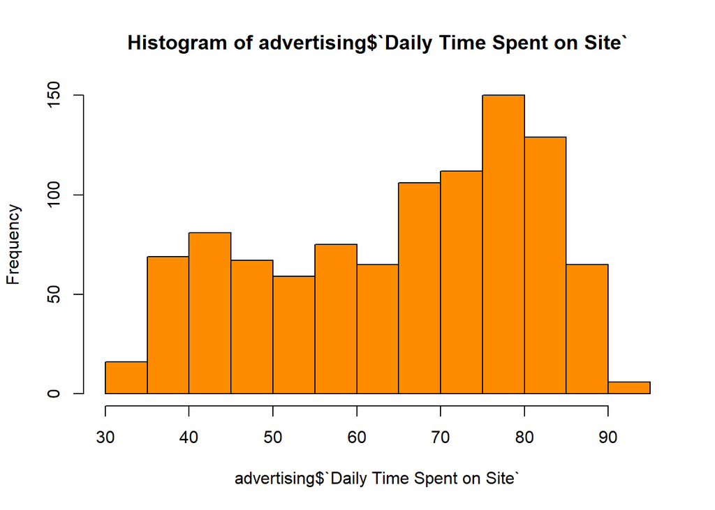

```r
#distribution
hist(advertising$`Daily Time Spent on Site`, col=c("darkorange"))
```

The users spend an average 65.002 minutes on the website. The modal time is “62.26” “75.55” “77.05” “78.76” “84.53” The median time is 68.215. The distribution above is left-skewed. The highest frequency is 80 units of time(minutes).

Age

```r
# Age of the user
#This column represents the Age of the user
# measures of central tendency

summary(advertising$Age)
```

```
##    Min. 1st Qu.  Median    Mean 3rd Qu.    Max.
##   19.00   29.00   35.00   36.01   42.00   61.00
```

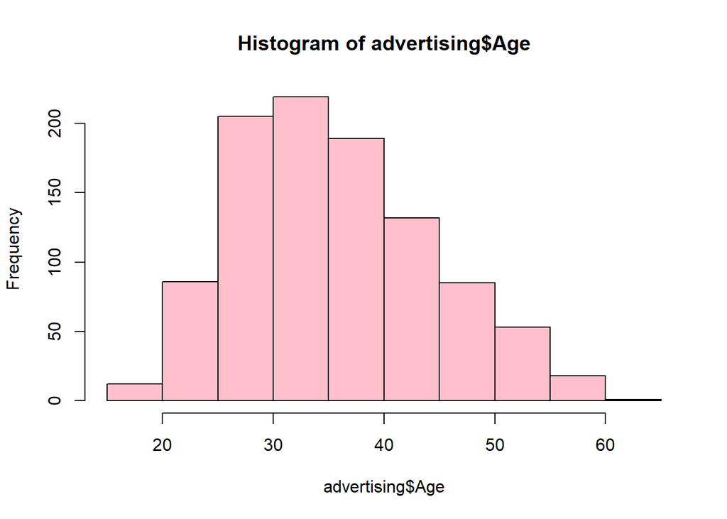

```r
#distribution
hist(advertising$Age, col = c("pink"))
```

The age distribution is right skewed The respondents on the website are mostly 25-40 years old. The mean age is 36. The median age is 35

AreaIncome

```r
# Age of the user
#This column represents the Age of the user
# measures of central tendency

summary(advertising$`Area Income`)
```

```
##    Min. 1st Qu.  Median    Mean 3rd Qu.    Max.
##   13996   47032   57012   55000   65471   79485
```

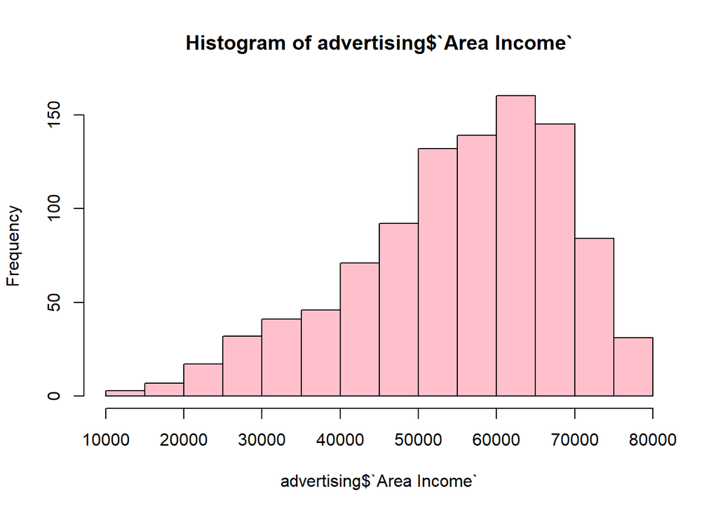

```r
#distribution
hist(advertising$`Area Income`, col = c("pink"))
```

The income distribution is left skewed The respondents on the website mostly earn between 55,000 to 70,000. The mean income is 55,000. The median income is 57,012.

DailyInternet Usage

```r
# Age of the user
#This column represents the Age of the user
# measures of central tendency

summary(advertising$`Daily Internet Usage`)
```

```
##    Min. 1st Qu.  Median    Mean 3rd Qu.    Max.
##   104.8   138.8   183.1   180.0   218.8   270.0
```

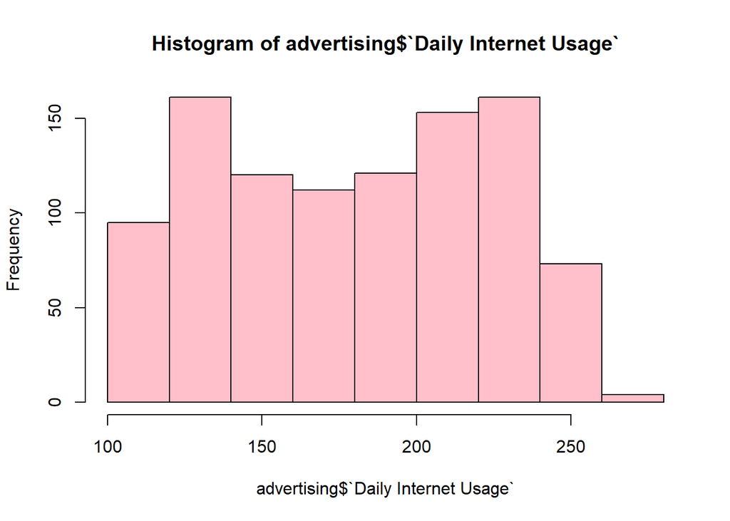

```r
#distribution
hist(advertising$`Daily Internet Usage`, col = c("pink"))
```

Ad Topic Line

```r
#
Ad_topic_line <- advertising$Ad.Topic.Line
#all the values are unique in this column thus we would drop it whenmodelling since it
#does not provide any additional meaningful information
levels(unique(Ad_topic_line))
```

```r
factor(unique(Ad_topic_line))
```

```
## factor(0)
## Levels:
```

Male

```r
#gender of the user
#1 indicates that the user is male while indicates that they are female
# measures of central tendency
#levels(advert_df$Male) #this code does not work
#obtaining the unique levels in the gender(Male column)
unique(factor(advertising$Male))
```

```
## [1] 0 1
## Levels: 0 1
```

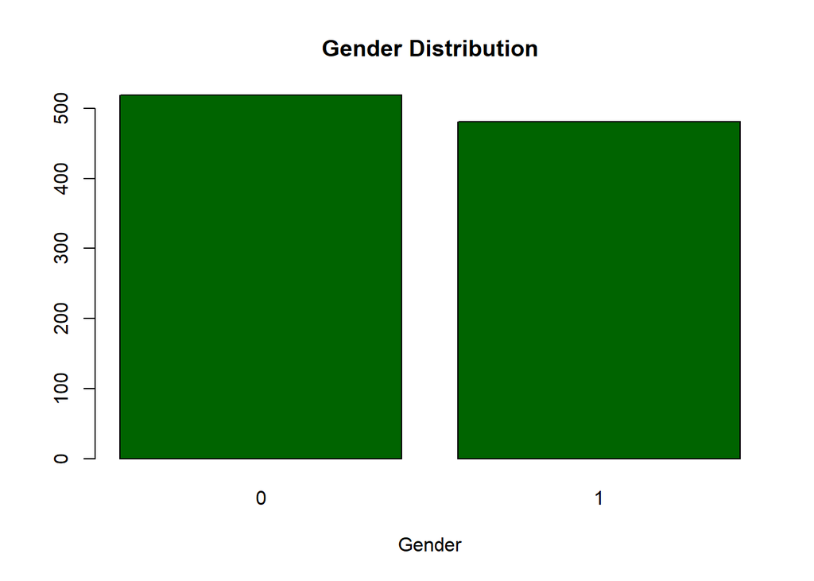

```r
Male_x <- table(advertising$Male)
#distribution
barplot(Male_x, main="Gender Distribution",col=c("darkgreen"),xlab="Gender")
```

Clicked.on.Ad

```r
#zero indicates that a user did not click on an add while 1 indicates that auser clicked on an add
# measures of central tendency

table(advertising$`Clicked on Ad`)
```

```
##
##   0   1
## 500 500
```

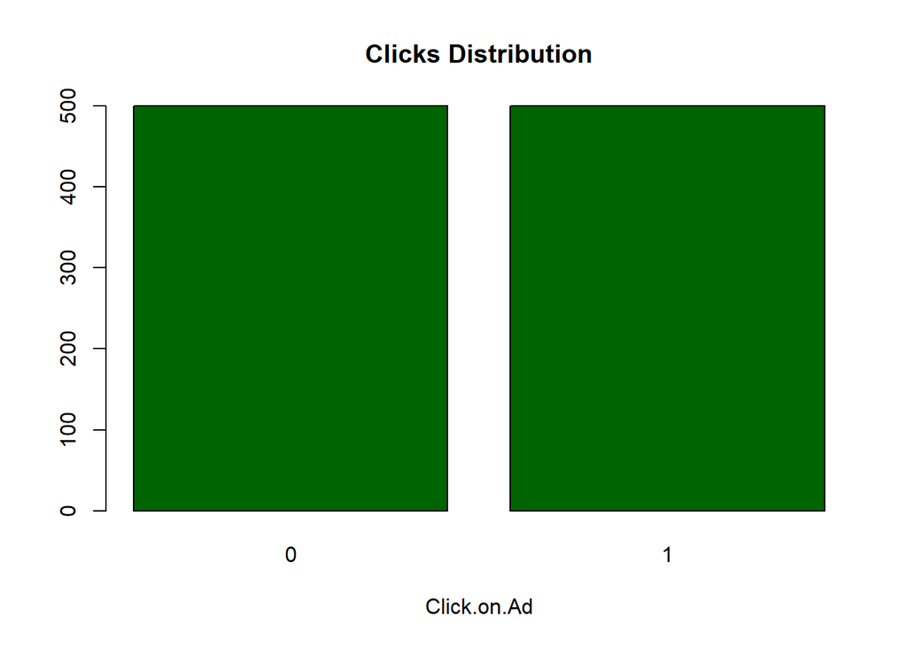

```r
Male_x <- table(advertising$`Clicked on Ad`)
#distribution
barplot(Male_x, main="Clicks Distribution",col=c("darkgreen"),xlab="Click.on.Ad")
```

BVivariate Analysis

```r
head(advertising)
```

```
##    Daily Time Spent on Site Age Area Income Daily Internet Usage
## 1:                    68.95  35    61833.90               256.09
## 2:                    80.23  31    68441.85               193.77
## 3:                    69.47  26    59785.94               236.50
## 4:                    74.15  29    54806.18               245.89
## 5:                    68.37  35    73889.99               225.58
## 6:                    59.99  23    59761.56               226.74
##                            Ad Topic Line           City Male    Country
## 1:    Cloned 5thgeneration orchestration    Wrightburgh    0    Tunisia
## 2:    Monitored national standardization      West Jodi    1      Nauru
## 3:      Organic bottom-line service-desk       Davidton    0 San Marino
## 4: Triple-buffered reciprocal time-frame West Terrifurt    1      Italy
## 5:         Robust logistical utilization   South Manuel    0    Iceland
## 6:       Sharable client-driven software      Jamieberg    1     Norway
##     Timestamp Clicked on Ad
## 1: 2016-03-27             0
## 2: 2016-04-04             0
## 3: 2016-03-13             0
## 4: 2016-01-10             0
## 5: 2016-06-03             0
## 6: 2016-05-19             0
```

```r
df2 <- subset(advertising, select = c(1,2,3,4,7,10))

df2
```

```
##       Daily Time Spent on Site Age Area Income Daily Internet Usage Male
##    1:                    68.95  35    61833.90               256.09    0
##    2:                    80.23  31    68441.85               193.77    1
##    3:                    69.47  26    59785.94               236.50    0
##    4:                    74.15  29    54806.18               245.89    1
##    5:                    68.37  35    73889.99               225.58    0
##   ---
##  996:                    72.97  30    71384.57               208.58    1
##  997:                    51.30  45    67782.17               134.42    1
##  998:                    51.63  51    42415.72               120.37    1
##  999:                    55.55  19    41920.79               187.95    0
## 1000:                    45.01  26    29875.80               178.35    0
##       Clicked on Ad
##    1:             0
##    2:             0
##    3:             0
##    4:             0
##    5:             0
##   ---
##  996:             1
##  997:             1
##  998:             1
##  999:             0
## 1000:             1
```

Correlation

```r
#The default method is Pearson, but we can also compute Spearman or Kendallcoefficients.
mydata = cor(df2, method = c("spearman"))
mydata1= cor(df2, method = c("kendall"))
mydata2= cor(df2, method = c("pearson"))

mydata #spearman
```

```
##                          Daily Time Spent on Site         Age Area Income
## Daily Time Spent on Site               1.00000000 -0.31686155  0.28313439
## Age                                   -0.31686155  1.00000000 -0.13595396
## Area Income                            0.28313439 -0.13595396  1.00000000
## Daily Internet Usage                   0.51410805 -0.37086395  0.33916021
## Male                                  -0.01592213 -0.02315468 -0.01436909
## Clicked on Ad                         -0.74487253  0.48633733 -0.46722440
##                          Daily Internet Usage        Male Clicked on Ad
## Daily Time Spent on Site           0.51410805 -0.01592213   -0.74487253
## Age                               -0.37086395 -0.02315468    0.48633733
## Area Income                        0.33916021 -0.01436909   -0.46722440
## Daily Internet Usage               1.00000000  0.02820432   -0.77660702
## Male                               0.02820432  1.00000000   -0.03802747
## Clicked on Ad                     -0.77660702 -0.03802747    1.00000000
```

```r
mydata1 #kendall
```

```
##                          Daily Time Spent on Site         Age Area Income
## Daily Time Spent on Site               1.00000000 -0.19668659  0.16578119
## Age                                   -0.19668659  1.00000000 -0.08005810
## Area Income                            0.16578119 -0.08005810  1.00000000
## Daily Internet Usage                   0.29323600 -0.23244607  0.20837546
## Male                                  -0.01300823 -0.01921715 -0.01173817
## Clicked on Ad                         -0.60855366  0.40363397 -0.38167782
##                          Daily Internet Usage        Male Clicked on Ad
## Daily Time Spent on Site           0.29323600 -0.01300823   -0.60855366
## Age                               -0.23244607 -0.01921715    0.40363397
## Area Income                        0.20837546 -0.01173817   -0.38167782
## Daily Internet Usage               1.00000000  0.02304102   -0.63443547
## Male                               0.02304102  1.00000000   -0.03802747
## Clicked on Ad                     -0.63443547 -0.03802747    1.00000000
```

```r
mydata2 #pearson
```

```
##                          Daily Time Spent on Site         Age  Area Income
## Daily Time Spent on Site               1.00000000 -0.33151334  0.310954413
## Age                                   -0.33151334  1.00000000 -0.182604955
## Area Income                            0.31095441 -0.18260496  1.000000000
## Daily Internet Usage                   0.51865848 -0.36720856  0.337495533
## Male                                  -0.01895085 -0.02104406  0.001322359
## Clicked on Ad                         -0.74811656  0.49253127 -0.476254628
##                          Daily Internet Usage         Male Clicked on Ad
## Daily Time Spent on Site           0.51865848 -0.018950855   -0.74811656
## Age                               -0.36720856 -0.021044064    0.49253127
## Area Income                        0.33749553  0.001322359   -0.47625463
## Daily Internet Usage               1.00000000  0.028012326   -0.78653918
## Male                               0.02801233  1.000000000   -0.03802747
## Clicked on Ad                     -0.78653918 -0.038027466    1.00000000
```

#Generating P values

```r
#install_version("latticeExtra")
#install.packages("Hmisc", dependencies = T)
library("Hmisc")
mydata.rcorr = rcorr(as.matrix(mydata)) #feed the data as a matrix
mydata.rcorr
```

```
##                          Daily Time Spent on Site   Age Area Income
## Daily Time Spent on Site                     1.00 -0.79        0.65
## Age                                         -0.79  1.00       -0.61
## Area Income                                  0.65 -0.61        1.00
## Daily Internet Usage                         0.88 -0.83        0.70
## Male                                        -0.08 -0.15       -0.15
## Clicked on Ad                               -0.95  0.85       -0.77
##                          Daily Internet Usage  Male Clicked on Ad
## Daily Time Spent on Site                 0.88 -0.08         -0.95
## Age                                     -0.83 -0.15          0.85
## Area Income                              0.70 -0.15         -0.77
## Daily Internet Usage                     1.00 -0.03         -0.97
## Male                                    -0.03  1.00          0.00
## Clicked on Ad                           -0.97  0.00          1.00
##
## n= 6
##
##
## P
##                          Daily Time Spent on Site Age    Area Income
## Daily Time Spent on Site                          0.0626 0.1620
## Age                      0.0626                          0.1966
## Area Income              0.1620                   0.1966
## Daily Internet Usage     0.0213                   0.0422 0.1252
## Male                     0.8853                   0.7736 0.7717
## Clicked on Ad            0.0034                   0.0335 0.0742
##                          Daily Internet Usage Male   Clicked on Ad
## Daily Time Spent on Site 0.0213               0.8853 0.0034
## Age                      0.0422               0.7736 0.0335
## Area Income              0.1252               0.7717 0.0742
## Daily Internet Usage                          0.9623 0.0015
## Male                     0.9623                      0.9936
## Clicked on Ad            0.0015               0.9936
```

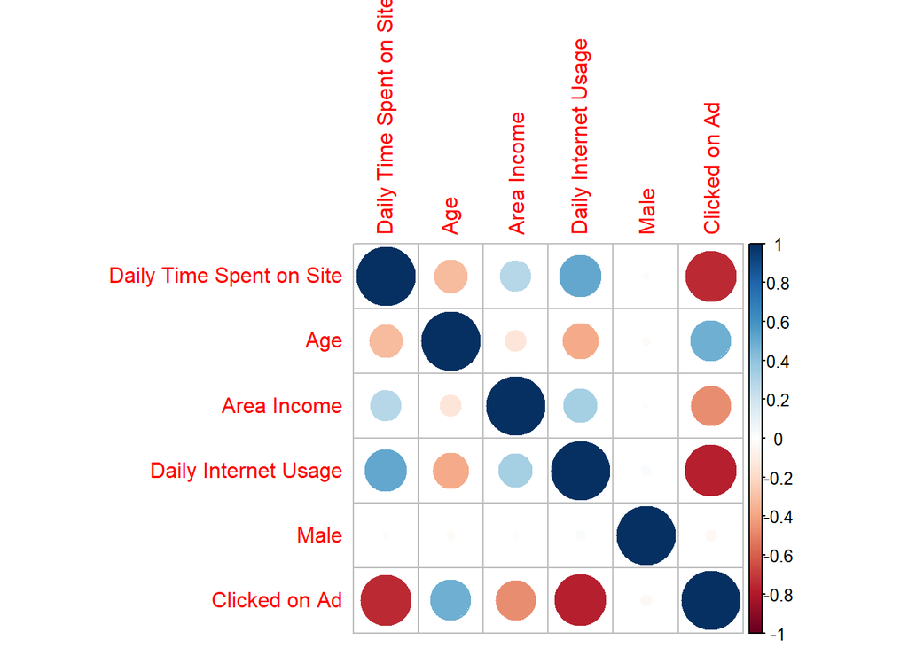

```r
#mydata.coeff = mydata.rcorr$r
#mydata.p = mydata.rcorr$P
library(corrplot)
## corrplot 0.84 loaded
corrplot(mydata)
```

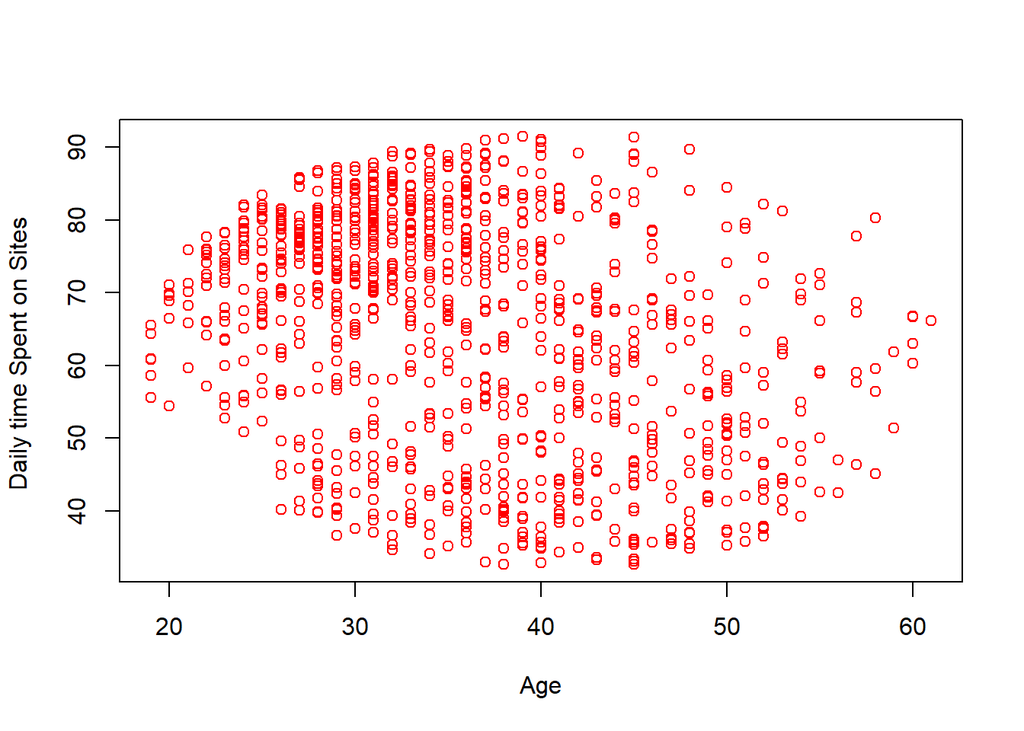

```r
plot( advertising$`Age`,advertising$`Daily Time Spent on Site`, xlab = "Age", ylab = "Daily time Spent on Sites ", col = "red")
```

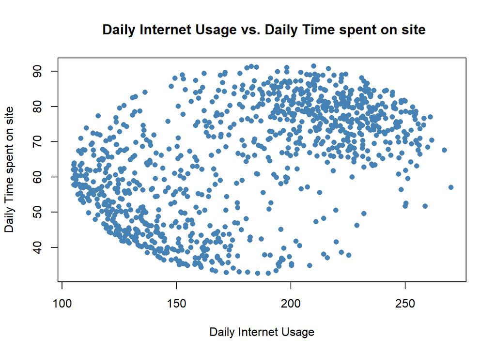

```r
#create scatterplot of Daily Internet Usage vs. Time spent on site
plot(advertising$`Daily Internet Usage`, advertising$`Daily Time Spent on Site`, pch=16, col='steelblue',
     main=' Daily Internet Usage vs. Daily Time spent on site',
     xlab='Daily Internet Usage', ylab='Daily Time spent on site')
```

People with high daily internet usage spend higher time on sites

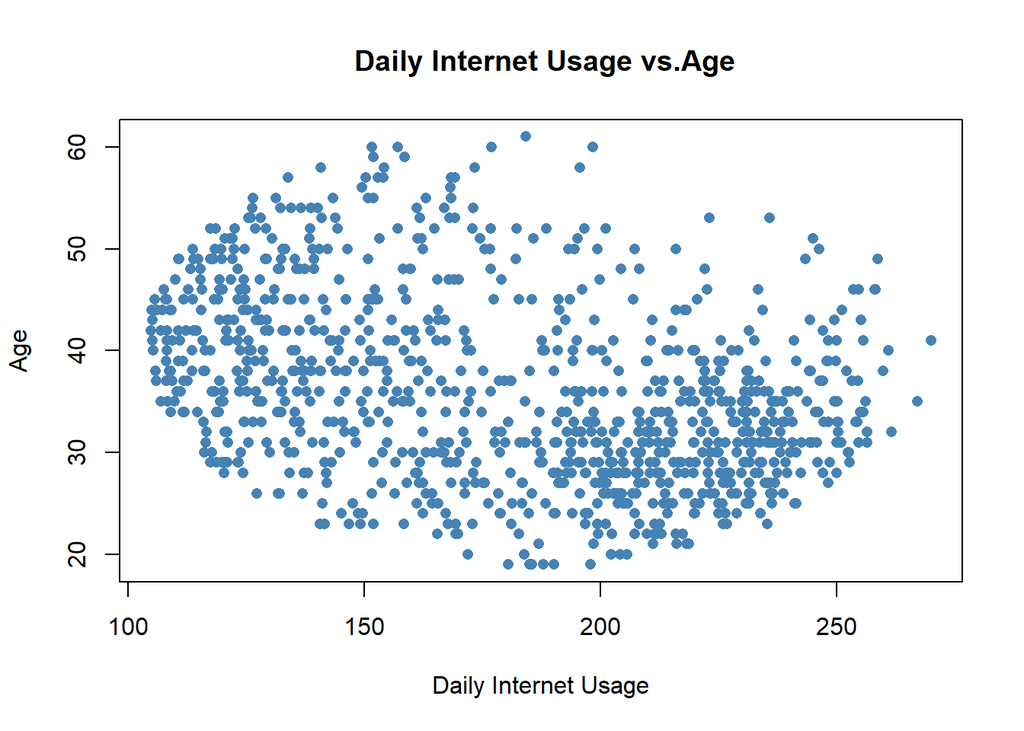

```r
#create scatterplot of Daily Internet Usage vs. Time spent on site
plot(advertising$`Daily Internet Usage`, advertising$`Age`, pch=16, col='steelblue',
     main=' Daily Internet Usage vs.Age',
     xlab='Daily Internet Usage', ylab='Age')
```

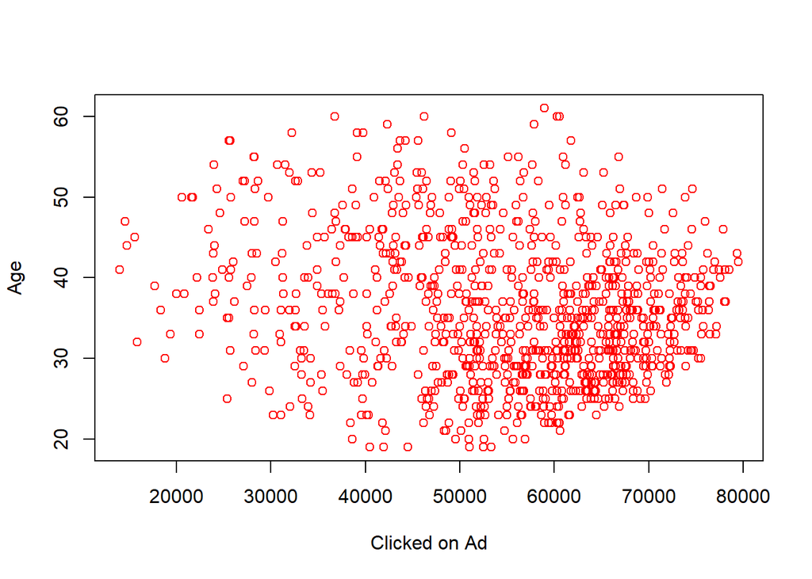

```r
plot(advertising$`Area Income` ,advertising$`Age`, xlab= "Clicked on Ad", ylab = "Age", col = "red")
```

People with high Area income are aged between 30 and Above

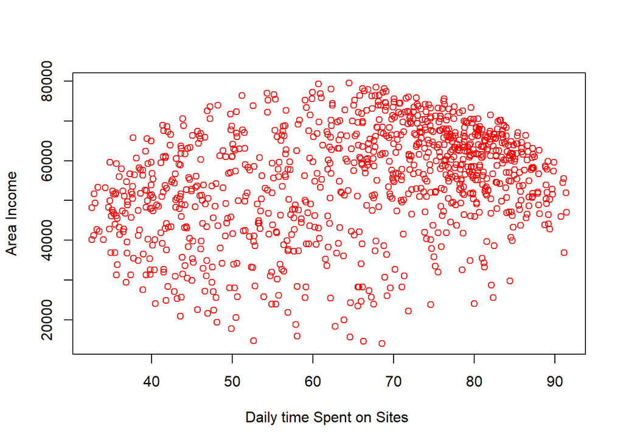

```r
plot( advertising$`Daily Time Spent on Site`,advertising$`Area Income`, xlab = "Daily time Spent on Sites ", ylab = "Area Income", col = "red")
```

#positive non-linear correlation People with High area income spend more time on sites

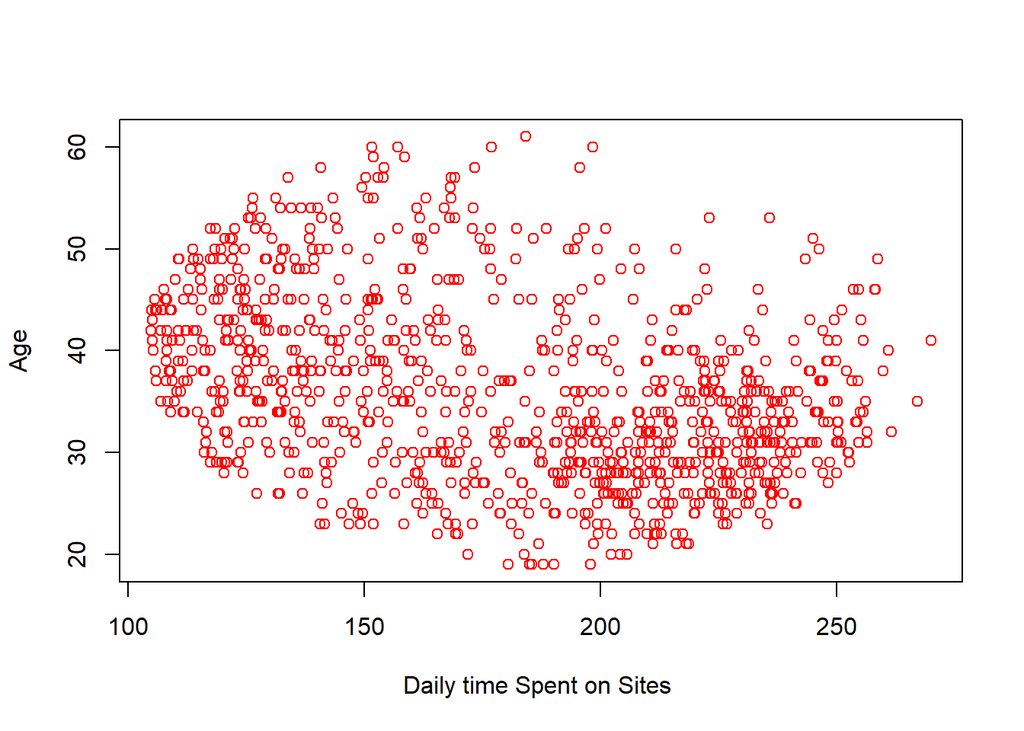

```r
plot( advertising$`Daily Internet Usage`,advertising$Age, xlab = "Daily time Spent on Sites ", ylab = "Age", col = "red")
```

People aged 30 and below have high internet usage Seperating the data Clicked and Gender columns

```r
#populating the column with false values from the male column
df2$Female <- df2$Male == 0

dim(df2)
```

```
## [1] 1000    7
```

```r
#converting the column to nu,eric
dim(df2 <- apply(df2, 2, as.numeric))
```

```
## [1] 1000    7
```

Gender VS Clicked on Add

```r
library(tidyverse)

#Male respondents who clicked on an add
dim(advertising%>% filter(Male == 1 , `Clicked on Ad` == 1))
```

```
## [1] 231  10
```

```r
#Male respondents did not click on an add
dim(advertising%>% filter(Male == 1, `Clicked on Ad` == 0))
```

```
## [1] 250  10
```

```r
#Female respondents who clicked on an add
dim(advertising%>% filter(Male == 0 , `Clicked on Ad` == 1))
```

```
## [1] 269  10
```

```r
#Female respondents who clicked did not on an add
dim(advertising%>% filter(Male == 0, `Clicked on Ad` == 0))
```

```
## [1] 250  10
```

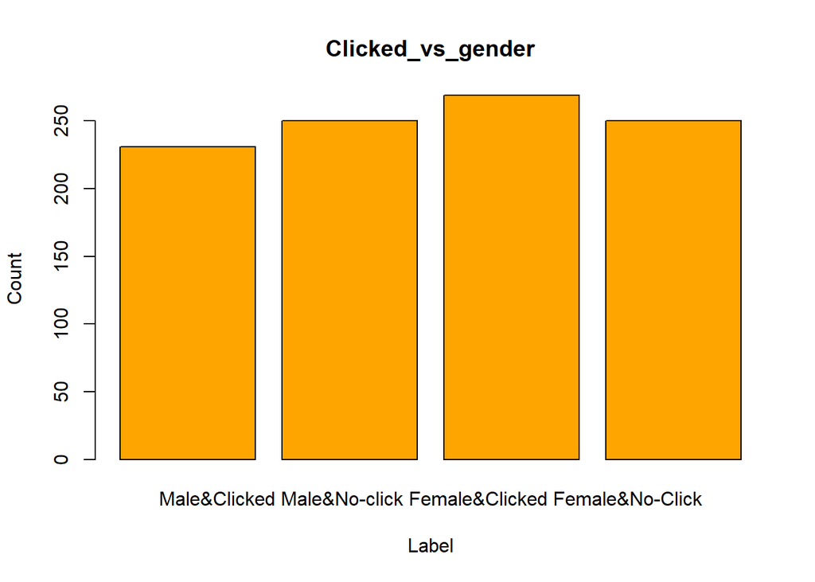

```r
Clicked_vs_gender <- c( 231 , 250 , 269 , 250 )

# barchart with added parameters
barplot(Clicked_vs_gender, main = " Clicked_vs_gender " , xlab = " Label ",
ylab = " Count ",
names.arg = c("Male&Clicked Male&No-click Female&Clicked Female&No-Click"),
col = "Orange",
horiz = FALSE)
```

Multivariate Analysis

```r
# A glimpse of the data
library(dplyr)
glimpse(df2)
```

```
##  num [1:1000, 1:7] 69 80.2 69.5 74.2 68.4 ...
##  - attr(*, "dimnames")=List of 2
##   ..$ : NULL
##   ..$ : chr [1:7] "Daily Time Spent on Site" "Age" "Area Income" "Daily Internet Usage" ...
```

```r
head(df2)
```

```
##      Daily Time Spent on Site Age Area Income Daily Internet Usage Male
## [1,]                    68.95  35    61833.90               256.09    0
## [2,]                    80.23  31    68441.85               193.77    1
## [3,]                    69.47  26    59785.94               236.50    0
## [4,]                    74.15  29    54806.18               245.89    1
## [5,]                    68.37  35    73889.99               225.58    0
## [6,]                    59.99  23    59761.56               226.74    1
##      Clicked on Ad Female
## [1,]             0      1
## [2,]             0      0
## [3,]             0      1
## [4,]             0      0
## [5,]             0      1
## [6,]             0      0
```

```r
# One hot encoding of the factor variables.
library(caret)
## Loading required package: lattice
dmy <- dummyVars(" ~ .", data = df2, fullRank = T)
dummy_df <- data.frame(predict(dmy, newdata = df2))
#print(dummy_df)
glimpse(dummy_df)
```

```
## Rows: 1,000
## Columns: 7
## $ X.Daily.Time.Spent.on.Site. <dbl> 68.95, 80.23, 69.47, 74.15, 68.37, 59.99, ~
## $ Age                         <dbl> 35, 31, 26, 29, 35, 23, 33, 48, 30, 20, 49~
## $ X.Area.Income.              <dbl> 61833.90, 68441.85, 59785.94, 54806.18, 73~
## $ X.Daily.Internet.Usage.     <dbl> 256.09, 193.77, 236.50, 245.89, 225.58, 22~
## $ Male                        <dbl> 0, 1, 0, 1, 0, 1, 0, 1, 1, 1, 0, 1, 1, 0, ~
## $ X.Clicked.on.Ad.            <dbl> 0, 0, 0, 0, 0, 0, 0, 1, 0, 0, 1, 0, 1, 0, ~
## $ Female                      <dbl> 1, 0, 1, 0, 1, 0, 1, 0, 0, 0, 1, 0, 0, 1, ~
```

```r
sapply(dummy_df, class)
```

```
## X.Daily.Time.Spent.on.Site.                         Age
##                   "numeric"                   "numeric"
##              X.Area.Income.     X.Daily.Internet.Usage.
##                   "numeric"                   "numeric"
##                        Male            X.Clicked.on.Ad.
##                   "numeric"                   "numeric"
##                      Female
##                   "numeric"
```

```r
dummy_df2 <-dummy_df[c(1,2,3,4,5,6)]

dim(dummy_df2)
```

```
## [1] 1000    6
```

```r
#6 columns in dummy_df2
```

```r
dummy_df.class<- df2[,6]
```

Scaling

```r
dummy_df2_scaled <- scale(dummy_df2)
summary(dummy_df2_scaled)
```

```
##  X.Daily.Time.Spent.on.Site.      Age          X.Area.Income.
##  Min.   :-2.0437             Min.   :-1.9360   Min.   :-3.0566
##  1st Qu.:-0.8604             1st Qu.:-0.7978   1st Qu.:-0.5940
##  Median : 0.2028             Median :-0.1148   Median : 0.1500
##  Mean   : 0.0000             Mean   : 0.0000   Mean   : 0.0000
##  3rd Qu.: 0.8545             3rd Qu.: 0.6819   3rd Qu.: 0.7805
##  Max.   : 1.6671             Max.   : 2.8446   Max.   : 1.8252
##  X.Daily.Internet.Usage.      Male         X.Clicked.on.Ad.
##  Min.   :-1.71335        Min.   :-0.9622   Min.   :-0.9995
##  1st Qu.:-0.93777        1st Qu.:-0.9622   1st Qu.:-0.9995
##  Median : 0.07129        Median :-0.9622   Median : 0.0000
##  Mean   : 0.00000        Mean   : 0.0000   Mean   : 0.0000
##  3rd Qu.: 0.88361        3rd Qu.: 1.0382   3rd Qu.: 0.9995
##  Max.   : 2.04909        Max.   : 1.0382   Max.   : 0.9995
```

```r
dummy_df2_norm <- as.data.frame(apply(dummy_df2, 2, function(x) (x -
min(x))/(max(x)-min(x))))
summary(dummy_df2_norm)
```

```
##  X.Daily.Time.Spent.on.Site.      Age         X.Area.Income.
##  Min.   :0.0000              Min.   :0.0000   Min.   :0.0000
##  1st Qu.:0.3189              1st Qu.:0.2381   1st Qu.:0.5044
##  Median :0.6054              Median :0.3810   Median :0.6568
##  Mean   :0.5507              Mean   :0.4050   Mean   :0.6261
##  3rd Qu.:0.7810              3rd Qu.:0.5476   3rd Qu.:0.7860
##  Max.   :1.0000              Max.   :1.0000   Max.   :1.0000
##  X.Daily.Internet.Usage.      Male       X.Clicked.on.Ad.
##  Min.   :0.0000          Min.   :0.000   Min.   :0.0
##  1st Qu.:0.2061          1st Qu.:0.000   1st Qu.:0.0
##  Median :0.4743          Median :0.000   Median :0.5
##  Mean   :0.4554          Mean   :0.481   Mean   :0.5
##  3rd Qu.:0.6902          3rd Qu.:1.000   3rd Qu.:1.0
##  Max.   :1.0000          Max.   :1.000   Max.   :1.0
```

```r
library(factoextra)
```

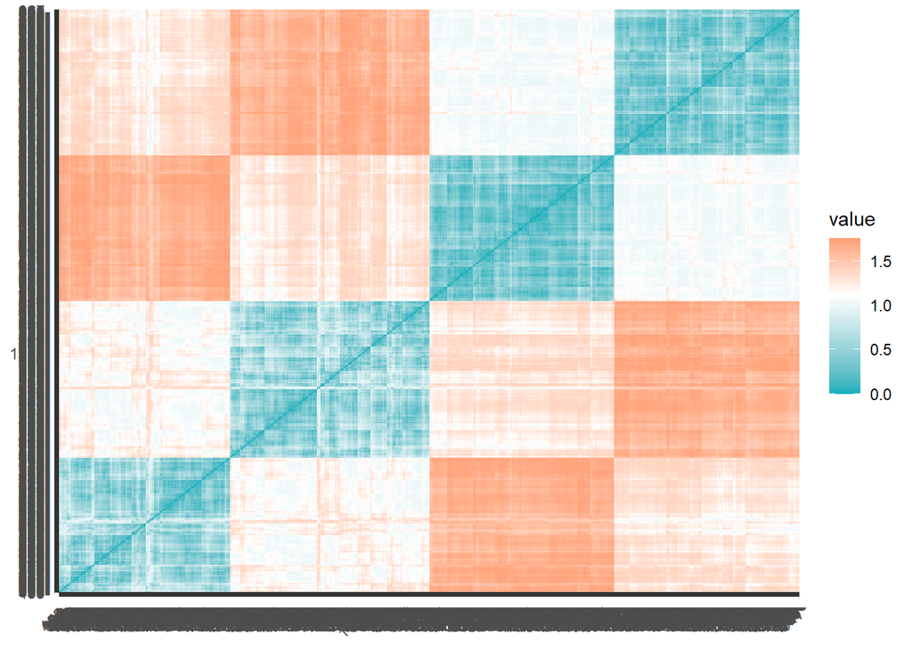

```r
## Welcome! Want to learn more? See two factoextra-related books at

distance <- get_dist(dummy_df2_norm)
fviz_dist(distance, gradient = list(low = "#00AFBB", mid = "white", high ="#FC4E07"))
```

Finding the Optimal number of clusters

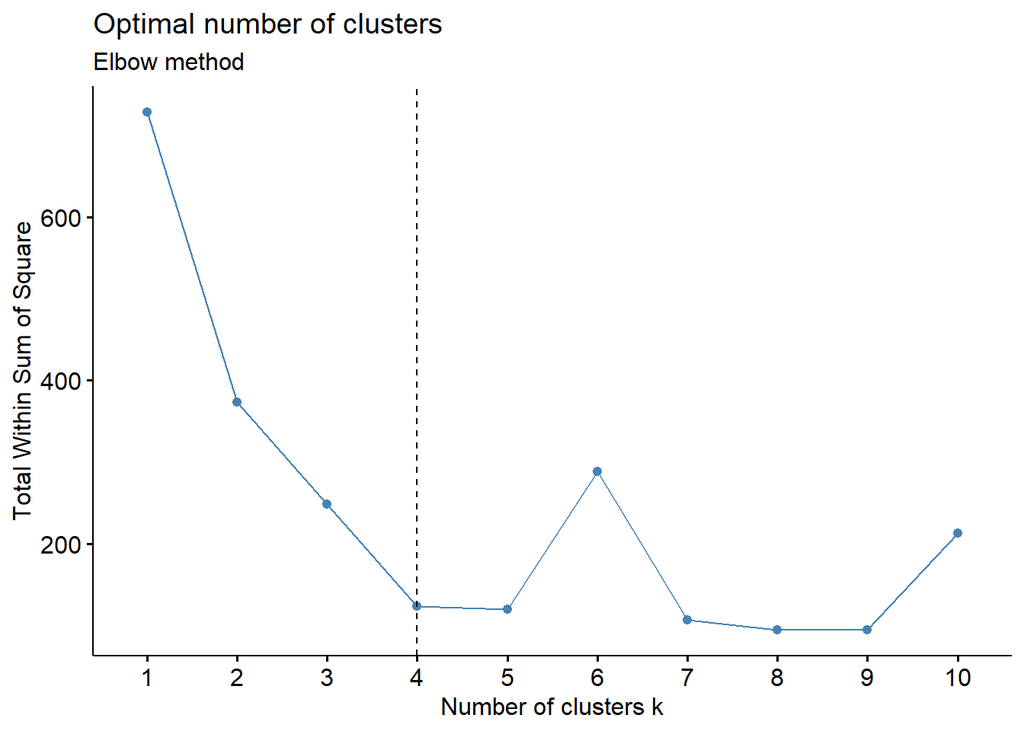

```r
# Elbow method
# Searching for the optimal number of clusters
# # Elbow method
# Searching for the optimal number of clusters
# # Elbow method
library(factoextra)

fviz_nbclust(dummy_df2_norm, kmeans, method = "wss") +
 geom_vline(xintercept = 4, linetype = 2)+
 labs(subtitle = "Elbow method")
```

Linear Regression_Baseline Model

```r
head(dummy_df2_norm)
```

```
##   X.Daily.Time.Spent.on.Site.       Age X.Area.Income. X.Daily.Internet.Usage.
## 1                   0.6178820 0.3809524      0.7304725               0.9160310
## 2                   0.8096209 0.2857143      0.8313752               0.5387456
## 3                   0.6267211 0.1666667      0.6992003               0.7974331
## 4                   0.7062723 0.2380952      0.6231599               0.8542802
## 5                   0.6080231 0.3809524      0.9145678               0.7313234
## 6                   0.4655788 0.0952381      0.6988280               0.7383460
##   Male X.Clicked.on.Ad.
## 1    0                0
## 2    1                0
## 3    0                0
## 4    1                0
## 5    0                0
## 6    1                0
```

```r
# Creating the relationship model
model1 <- lm(X.Clicked.on.Ad.~X.Daily.Time.Spent.on.Site.+Age+X.Area.Income.+X.Daily.Internet.Usage.+Male, data = dummy_df2_norm)
model1
```

```
##
## Call:
## lm(formula = X.Clicked.on.Ad. ~ X.Daily.Time.Spent.on.Site. +
##     Age + X.Area.Income. + X.Daily.Internet.Usage. + Male, data = dummy_df2_norm)
##
## Coefficients:
##                 (Intercept)  X.Daily.Time.Spent.on.Site.
##                     1.42460                     -0.75270
##                         Age               X.Area.Income.
##                     0.37727                     -0.40425
##     X.Daily.Internet.Usage.                         Male
##                    -0.86885                     -0.02926
```

```r
summary(model1)
```

```
##
## Call:
## lm(formula = X.Clicked.on.Ad. ~ X.Daily.Time.Spent.on.Site. +
##     Age + X.Area.Income. + X.Daily.Internet.Usage. + Male, data = dummy_df2_norm)
##
## Residuals:
##      Min       1Q   Median       3Q      Max
## -0.65251 -0.11577 -0.03069  0.05081  1.03147
##
## Coefficients:
##                             Estimate Std. Error t value Pr(>|t|)
## (Intercept)                  1.42460    0.03167  44.981   <2e-16 ***
## X.Daily.Time.Spent.on.Site. -0.75270    0.02976 -25.294   <2e-16 ***
## Age                          0.37727    0.03479  10.845   <2e-16 ***
## X.Area.Income.              -0.40425    0.03504 -11.536   <2e-16 ***
## X.Daily.Internet.Usage.     -0.86885    0.03084 -28.169   <2e-16 ***
## Male                        -0.02926    0.01333  -2.195   0.0284 *
## ---
## Signif. codes:  0 '***' 0.001 '**' 0.01 '*' 0.05 '.' 0.1 ' ' 1
##
## Residual standard error: 0.2104 on 994 degrees of freedom
## Multiple R-squared:  0.8241, Adjusted R-squared:  0.8232
## F-statistic: 931.2 on 5 and 994 DF,  p-value: < 2.2e-16
```